# Zillow Case Project - Starter Code 1

```r
# mean only changed from 22823 to 22923 (not that significant)
## check change in sd ...
sd(full$lotsizesquarefeet , na.rm=T)
```

```
## [1] 337585.6
```

```r
sd(full$lotsizesqft_imputed)
```

```
## [1] 374987.9
```

```r
(sd(full$lotsizesqft_imputed) -  sd(full$lotsizesquarefeet , na.rm=T)) / sd(full$lotsizesquarefeet , na.rm=T)
```

```
## [1] 0.1107935
```

```r
## 11% change in sd()
```

```r
full %>% filter(lotsizesquarefeet < calculatedfinishedsquarefeet) %>%
         select(parcelid, lotsizesquarefeet , calculatedfinishedsquarefeet,
                finishedfloor1squarefeet,
                finishedsquarefeet6,
                finishedsquarefeet12,
                finishedsquarefeet13,
                finishedsquarefeet15,
                finishedsquarefeet50
                ) %>% nrow()     ## comment out from %>% to view records in Markdown doc
```

```
## [1] 26072
```

```r
   ## unitcnt is NA for all of these
```

Finish up Tax Delinquincy and Fields from starterCode1

```r
## taxdelinquencyyear  (repeat from doc1)
class(full$taxdelinquencyyear)
```

```
## [1] "integer"
```

```r
unique(full$taxdelinquencyyear)
```

```
##  [1] NA 13 15 11 14  9 10  8 12  7  6  2 92  5  3  4 95 91 93 98 82 79 94
## [24] 97 90 99  0  1 87 84 86 88 96
```

```r
table(full$taxdelinquencyyear)
```

```
##
##     0     1     2     3     4     5     6     7     8     9    10    11
##     2     2     4     5    16    23    71   236   501  1016  1552  2351
##    12    13    14    15    79    82    84    86    87    88    90    91
##  3125  4633 16828 26071     2     1     1     1     1     1     2     2
##    92    93    94    95    96    97    98    99
##     5     3     2     5     1     2     3     4
```

```r
full <- full %>% mutate(taxdelinquencyyear4d = ifelse(is.na(taxdelinquencyyear), 0,
                                     ifelse(taxdelinquencyyear < 17, taxdelinquencyyear+2000, taxdelinquencyyear+1900)))

unique(full$taxdelinquencyyear4d)
```

```
##  [1]    0 2013 2015 2011 2014 2009 2010 2008 2012 2007 2006 2002 1992 2005
## [15] 2003 2004 1995 1991 1993 1998 1982 1979 1994 1997 1990 1999 2000 2001
## [29] 1987 1984 1986 1988 1996
```

```r
table(full$taxdelinquencyyear4d)
```

```
##
##       0    1979    1982    1984    1986    1987    1988    1990    1991
## 2928870       2       1       1       1       1       1       2       2
##    1992    1993    1994    1995    1996    1997    1998    1999    2000
##       5       3       2       5       1       2       3       4       2
##    2001    2002    2003    2004    2005    2006    2007    2008    2009
##       2       4       5      16      23      71     236     501    1016
##    2010    2011    2012    2013    2014    2015
##    1552    2351    3125    4633   16828   26071
```

```r
## repeate earlier rules from startercode1 to use them here as well
full <- full %>%
  mutate(taxdelinquencyflag = ifelse(is.na(taxdelinquencyflag), 0, ifelse(taxdelinquencyflag =="Y", 1, taxdelinquencyflag)),
         hashottuborspa = ifelse(is.na(hashottuborspa), 0, ifelse(hashottuborspa =="true", 1, hashottuborspa)),
         fireplaceflag = ifelse(is.na(fireplaceflag), 0, ifelse(fireplaceflag =="true", 1, fireplaceflag)),
         fireplacecnt = ifelse(is.na(fireplacecnt), 0, fireplacecnt)
  )

full <- full %>%
  mutate(taxdelinquencyflag = ifelse(!is.na(taxdelinquencyyear) & taxdelinquencyflag==0, 1, taxdelinquencyflag),
         fireplaceflag = ifelse(fireplacecnt > 0, 1, fireplaceflag),
         fireplacecnt = ifelse(fireplaceflag==1 & fireplacecnt == 0, -1, fireplacecnt)
         # -1 is a marker indicating that we need to impute these values if they exist
         # none were actually found when code was run but that may change with 2017 data in October
  )

unique(full$taxdelinquencyflag)
```

```
## [1] 0 1
```

```r
## check done ... no rule needed yet
full %>% select(taxdelinquencyflag, taxdelinquencyyear, taxdelinquencyyear4d) %>%
  filter(is.na(taxdelinquencyyear) & taxdelinquencyflag==1)  ## verified w/ other combination
```

```
## [1] taxdelinquencyflag   taxdelinquencyyear   taxdelinquencyyear4d
## <0 rows> (or 0-length row.names)
```

```r
                                                              ## nothing to return
```

```r
## check done ... no rule needed yet
full %>% select(taxdelinquencyflag, taxdelinquencyyear, taxdelinquencyyear4d) %>%
  filter(!is.na(taxdelinquencyyear) & taxdelinquencyflag==0)  ## verified w/ other combination
```

```
## [1] taxdelinquencyflag   taxdelinquencyyear   taxdelinquencyyear4d
## <0 rows> (or 0-length row.names)
```

```r
                                                              ## nothing to return
```

```r
## quick check before moving on
unique(full$taxdelinquencyyear4d)
```

```
##  [1]    0 2013 2015 2011 2014 2009 2010 2008 2012 2007 2006 2002 1992 2005
## [15] 2003 2004 1995 1991 1993 1998 1982 1979 1994 1997 1990 1999 2000 2001
## [29] 1987 1984 1986 1988 1996
```

```r
table(full$taxdelinquencyyear4d)
```

```
##
##       0    1979    1982    1984    1986    1987    1988    1990    1991
## 2928870       2       1       1       1       1       1       2       2
##    1992    1993    1994    1995    1996    1997    1998    1999    2000
##       5       3       2       5       1       2       3       4       2
##    2001    2002    2003    2004    2005    2006    2007    2008    2009
##       2       4       5      16      23      71     236     501    1016
##    2010    2011    2012    2013    2014    2015
##    1552    2351    3125    4633   16828   26071
```

```r
## new field: calculate number of years delinquent:
## -----------------
## if 0, house is not in delinquency
## If 1 or more, house is delinquent and this is the x year of delinquincy
## example: 2016 will come out as 1 for first year even though first year is not complete
##          this one field should now reflect full delinquency state
##          update variable: curYear to 2017 after new data comes out

curYear = 2016

full <- full %>%
  mutate(taxdelinquencyNoYrs = ifelse(taxdelinquencyyear4d == 0, 0, curYear - taxdelinquencyyear4d + 1))
```

```r
## spot check of values and ensure NAs are not present
unique(full$taxdelinquencyNoYrs)
```

```
##  [1]  0  4  2  6  3  8  7  9  5 10 11 15 25 12 14 13 22 26 24 19 35 38 23
## [24] 20 27 18 17 16 30 33 31 29 21
```

```r
table(full$taxdelinquencyNoYrs)
```

```
##
##       0       2       3       4       5       6       7       8       9
## 2928870   26071   16828    4633    3125    2351    1552    1016     501
##      10      11      12      13      14      15      16      17      18
##     236      71      23      16       5       4       2       2       4
##      19      20      21      22      23      24      25      26      27
##       3       2       1       5       2       3       5       2       2
##      29      30      31      33      35      38
##       1       1       1       1       1       2
```

Fields from set 2 having to do with Location (and related fields to help with imputation)

```r
## rerun missing calculations
missing = lapply(full, function(i) sum(is.na(i))/nrow(full)) # verity missingness
full$fips <- as.factor(full$fips)  # make fips a factor
```

```r
"FIPS:"
```

```
## [1] "FIPS:"
```

```r
levels(full$fips)
```

```
## [1] "6037" "6059" "6111"
```

```r
"FIPS Missing:"
```

```
## [1] "FIPS Missing:"
```

```r
missing$fips
```

```
## [1] 0.003831052
```

```r
"Latitude Missing:"
```

```
## [1] "Latitude Missing:"
```

```r
missing$latitude
```

```
## [1] 0.003831052
```

```r
"Longitude Records:"
```

```
## [1] "Longitude Records:"
```

```r
missing$longitude
```

```
## [1] 0.003831052
```

```r
## from spotcheck of test in StarterCode1:
## check these for relationship
                          ## Missingness:
# 'regionidcounty'        ## 0.3831212  (same as Lat/Long/fips)
# 'regionidcity'          ## 2.1052071
# 'regionidzip'           ## 0.4683077
# 'regionidneighborhood'  ## 61.2623806

## function used forgot to multiply by 100 ...
## so 0.0038... below is same as 0.38% above (still less than 1% though)
```

```r
## quick test of assumptions:
# how many records are missing all of these?: regionidcounty, latitude, longitude, fips? (miss % same)
library(mice)
full %>% select(regionidcity, latitude, longitude, fips) %>% md.pattern()
```

```
##         latitude longitude  fips regionidcity
## 2922495        1         1     1            1     0
##   51410        1         1     1            0     1
##   11437        0         0     0            0     4
##            11437     11437 11437        62847 97158
```

regioncityid is missing either when all 4 or missing or when the other 3 are present lattitude, longitude and fips always have values together so they can’t help w/ each other’s missingness

2922495 = rows where all 4 columns have values 51410 = rows where only regionidcity missing (from this set of 4 cols) 11437 = missing all 4 …

Final col: 0 cols missing data on this row 1 col missing data on this row 4 cols missing data on this row Total is totaling across rows subtotal so: 97158 data cells missing within this set of columns / rows (df)

```r
# full %>% select(regionidcity, latitude, longitude, fips) %>% filter(is.na(regionidcity) & !is.na(latitude)
#                                                                     & !is.na(longitude) & !is.na(fips))
#    ## above can help verify undersatnding of graph by switching is.na to !is.na ...

# library(mice)
full %>% select(regionidcity, latitude, longitude, fips,
                regionidcounty, regionidneighborhood, regionidzip) %>% md.pattern()
```

```
##         latitude longitude  fips regionidcounty regionidzip regionidcity
## 1156377        1         1     1              1           1            1
## 1765541        1         1     1              1           1            1
##      81        1         1     1              1           0            1
##   49444        1         1     1              1           1            0
##     496        1         1     1              1           0            1
##    1966        1         1     1              1           0            0
##   11437        0         0     0              0           0            0
##            11437     11437 11437          11437       13980        62847
##         regionidneighborhood
## 1156377                    1       0
## 1765541                    0       1
##      81                    1       1
##   49444                    0       2
##     496                    0       2
##    1966                    0       3
##   11437                    0       7
##                      1828884 1951459
```

Are corplots of these for complete values only helpful?

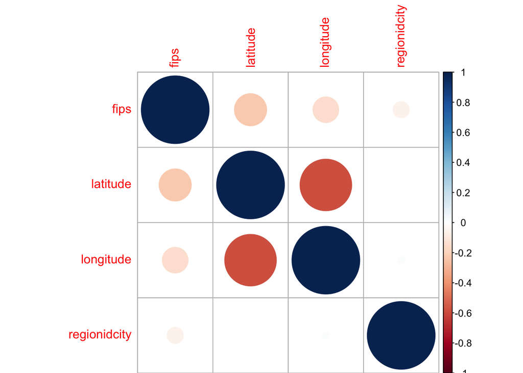

```r
# help with using grep/grepl in this context:
#      https://awakeningdatascientist.wordpress.com/2015/07/20/r-of-the-day-grep-and-grepl/

tmpCols1 = full[grepl('regionidcity|latitude|longitude|fips', names(full))]
tmpCols1 = as.data.frame(sapply(tmpCols1, as.numeric))  # note: fips factor converted to level values: 1,2,3
tmpCols2 = full[grepl('region|fips|latitude|longitude', names(full))]
tmpCols2 = as.data.frame(sapply(tmpCols2, as.numeric))  # note: fips factor converted to level values: 1,2,3
## convert to numeric first to use in cor plot (see above):
corrplot(cor(tmpCols1, use = "pairwise.complete.obs"))
```

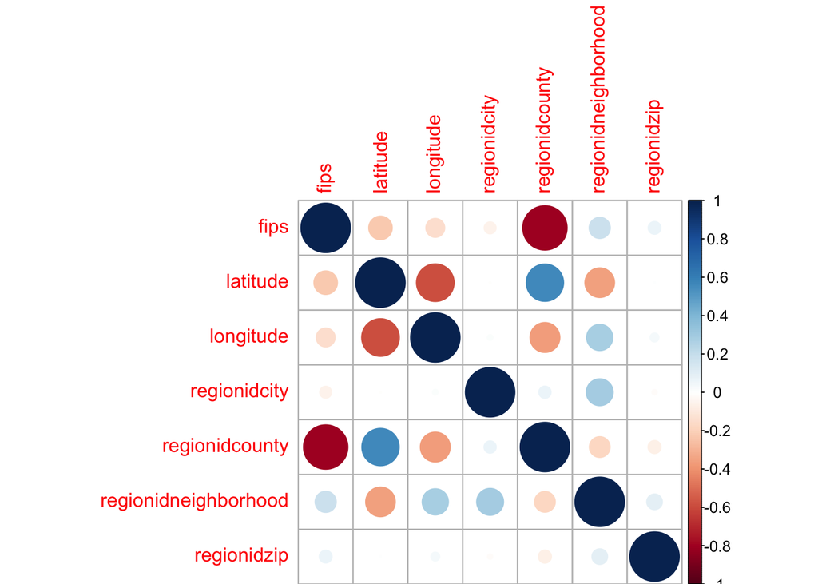

```r
corrplot(cor(tmpCols2, use="pairwise.complete.obs"))
```

Analysis:

```r
### for later step in cleaning process ... basic code to convert all specified string columns to factors from the df

# full_2 <- full  # synch up my two copies before moving forward ...
#
# factor_cols <- c("airconditioningtypeid",
#                  "fips",
#                  "heatingorsystemtypeid",
#                  "propertycountylandusecode",
#                  "propertylandusetypeid",
#                  "propertyzoningdesc",
#                  "rawcensustractandblock",
#                  "regionidcity",
#                  "regionidcounty",
#                  "regionidneighborhood",
#                  "regionidzip",
#                  "censustractandblock")
#
# ## convert columns to factors
# full_2 <- full_2 %>%
#   mutate_at(.funs = as.factor,
#             .vars = intersect(names(properties2), factor_cols))
```